# Chart Remake - Google Trends: Hangover Cure

This is a remake of chartr.co plot using tidyverse. The plot shows the google trend for “Hangover Cure” searches over a period of 90 days.

# Data 💰

We start by loading the data and printing first few rows.

```r
df <- read_csv("../data/us-90days.csv")
head(df, 3)
```

| Day | hangover cure: (United States) |
| --- | --- |
| 2020-05-30 | 55 |
| 2020-05-31 | 57 |
| 2020-06-01 | 20 |

Print some basic stats about our data.

```r
summary(df)
```

```
      Day             hangover cure: (United States)
 Min.   :2020-05-30   Min.   :  6.00
 1st Qu.:2020-06-21   1st Qu.: 16.00
 Median :2020-07-13   Median : 22.00
 Mean   :2020-07-13   Mean   : 29.63
 3rd Qu.:2020-08-04   3rd Qu.: 42.75
 Max.   :2020-08-27   Max.   :100.00
```

We are going to rename the columns to make it easier to reference them. And while we are at it, we will add weekday column that represents day of the week.

```r
df <- df %>%
  rename("Count"="hangover cure: (United States)") %>%
  mutate("weekday"=weekdays(Day))
```

# Plot 📈

We now everything we need to plot the data. Let us create the line chart and add other things on top of it.

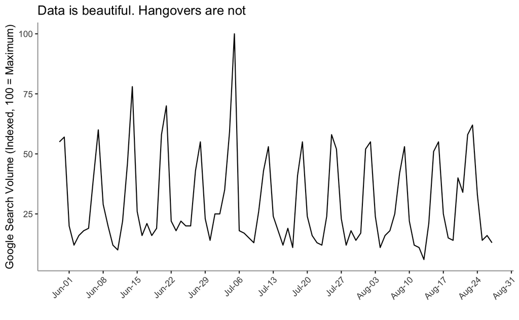

```r
library(ggplot2)
plt <- ggplot(df, aes(Day, Count)) +
  geom_line() +
  scale_x_date(date_breaks = "weeks", date_labels = "%b-%d") +
  labs(title = "Data is beautiful. Hangovers are not", x="", y="Google Search Volume (Indexed, 100 = Maximum)") +
  theme(axis.text.x = element_text(angle=45, hjust=1), panel.grid.major = element_blank(), panel.grid.minor = element_blank(),
        panel.background = element_blank(), axis.line = element_line(colour = "darkgray")
        )
plt
```

Next, We need to add the vertical lines to highlight the weekends.

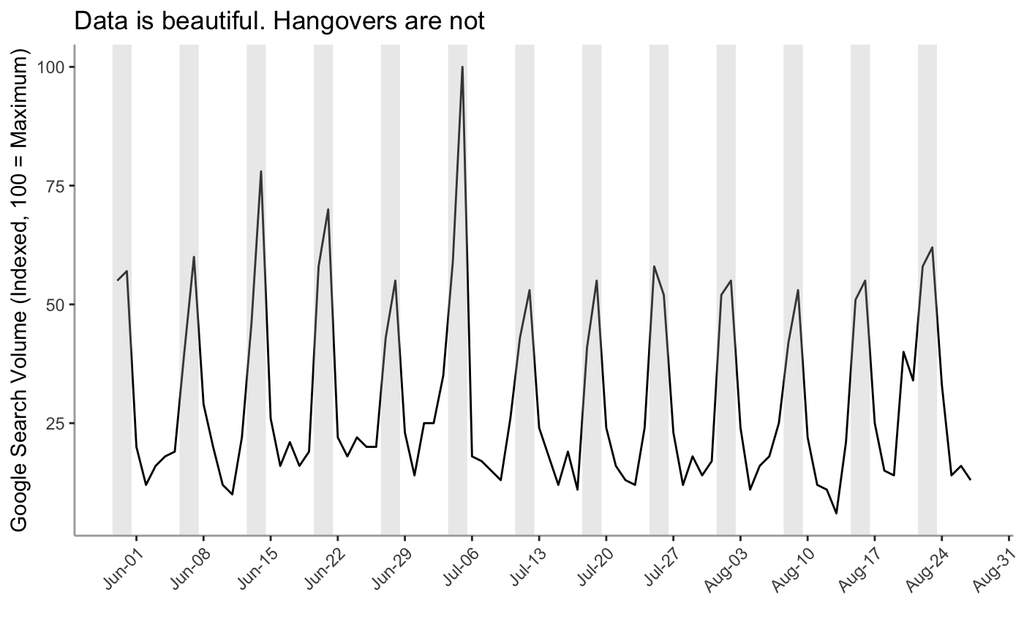

```r
plt <- plt + geom_vline(aes(xintercept=Day),
                 data=df %>% filter(weekday %in% c("Saturday", "Sunday")), color="gray",
                 alpha=0.3, size=2.3)
plt
```

Notice the huge spike around 6th of July - something to do with the long weeked, eh.

Now, all that is left is the annotation. and while we are at it, let’s center the title and add subtitle.

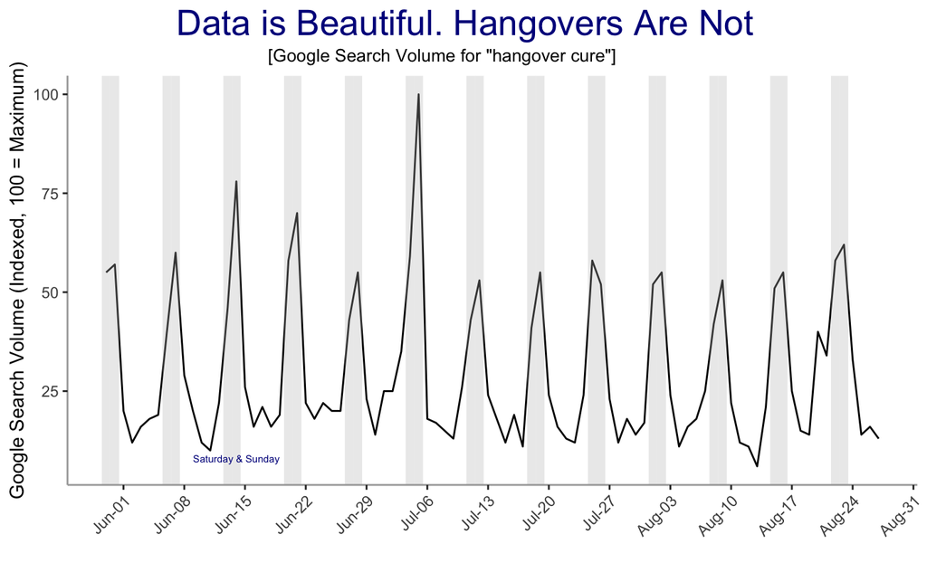

```r
weekends_df <- df %>% filter(weekday %in% c("Saturday", "Sunday"))
plt + annotate(geom = "text", x=weekends_df$Day[6], y=8, label="Saturday & Sunday", color="darkblue", size=2) +
  labs(title="Data is Beautiful. Hangovers Are Not", subtitle = "[Google Search Volume for \"hangover cure\"]") +
  theme(plot.title = element_text(size=20, colour = "darkblue", hjust = 0.4),
        plot.subtitle = element_text(size=10, colour = "black", hjust = 0.4))
```

And that’s it folks😎.